# Weight Lifting Exercise Dataset - prediction

Anna Witkowiak

26 10 2020

## Background

Using devices such as Jawbone Up, Nike FuelBand, and Fitbit it is now possible to collect a large amount of data about personal activity relatively inexpensively. These type of devices are part of the quantified self movement – a group of enthusiasts who take measurements about themselves regularly to improve their health, to find patterns in their behavior, or because they are tech geeks. One thing that people regularly do is quantify how much of a particular activity they do, but they rarely quantify how well they do it. In this project, your goal will be to use data from accelerometers on the belt, forearm, arm, and dumbell of 6 participants. They were asked to perform barbell lifts correctly and incorrectly in 5 different ways.

## Loading data and libraries

```r
library(caret)
```

```r
library(rpart)
library(rpart.plot)
library(randomForest)
training <- read.csv("~/Projekty/pml-training.csv", header = TRUE, na.strings = c('', 'NA'))
testing <- read.csv("~/Projekty/pml-testing.csv", header = TRUE, na.strings = c('', 'NA'))
```

## Cleaning data

```r
NAVAR    <- sapply(training, function(x) mean(is.na(x))) > 0.95
training <- training[, NAVAR==FALSE]
```

## Train and validation set

I need to split my training data into train and validation sets.

```r
set.seed(111)
inTrain  <- createDataPartition(training$classe, p=0.7, list=FALSE)
TrainSet <- training[inTrain, ]
ValSet  <- training[-inTrain, ]
```

## Models

Now it’s time to build models and decide which one is better.

### 1. Decision tree

A Decision Tree is a supervised learning predictive model that uses a set of binary rules to calculate a target value.

```r
set.seed(222)
modDecTree <- train(classe ~ .,method="rpart",data=TrainSet,trControl=trainControl(number=5,method="cv",verboseIter=TRUE,allowParallel=TRUE))
print(modDecTree$finalModel)
```

```
## n= 13737
##
## node), split, n, loss, yval, (yprob)
##       * denotes terminal node
##
## 1) root 13737 9831 A (0.28 0.19 0.17 0.16 0.18)
##   2) X< 5580 3906    0 A (1 0 0 0 0) *
##   3) X>=5580 9831 7173 B (0 0.27 0.24 0.23 0.26)
##     6) X< 9377.5 2658    0 B (0 1 0 0 0) *
##     7) X>=9377.5 7173 4648 E (0 0 0.33 0.31 0.35) *
```

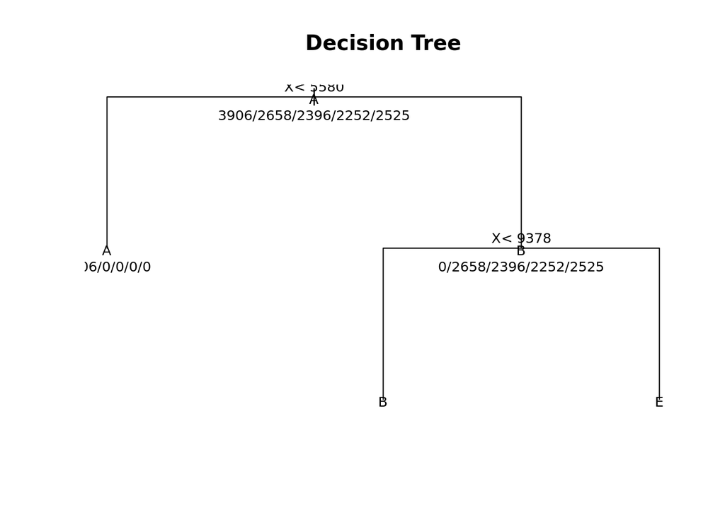

```r
plot(modDecTree$finalModel, uniform=TRUE,
      main="Decision Tree")
text(modDecTree$finalModel, use.n=TRUE, all=TRUE, cex=.8)
```

```r
predDecTree <- predict(modDecTree, newdata=ValSet)
confDecTree <- confusionMatrix(predDecTree, ValSet$classe)
confDecTree
```

```
## Confusion Matrix and Statistics
##
##           Reference
## Prediction    A    B    C    D    E
##          A 1673    0    0    0    0
##          B    1 1139    0    0    0
##          C    0    0    0    0    0
##          D    0    0    0    0    0
##          E    0    0 1026  964 1082
##
## Overall Statistics
##
##                Accuracy : 0.6617
##                  95% CI : (0.6494, 0.6738)
##     No Information Rate : 0.2845
##     P-Value [Acc > NIR] : < 2.2e-16
##
##                   Kappa : 0.5694
##
##  Mcnemar's Test P-Value : NA
##
## Statistics by Class:
##
##                      Class: A Class: B Class: C Class: D Class: E
## Sensitivity            0.9994   1.0000   0.0000   0.0000   1.0000
## Specificity            1.0000   0.9998   1.0000   1.0000   0.5857
## Pos Pred Value         1.0000   0.9991      NaN      NaN   0.3522
## Neg Pred Value         0.9998   1.0000   0.8257   0.8362   1.0000
## Prevalence             0.2845   0.1935   0.1743   0.1638   0.1839
## Detection Rate         0.2843   0.1935   0.0000   0.0000   0.1839
## Detection Prevalence   0.2843   0.1937   0.0000   0.0000   0.5220
## Balanced Accuracy      0.9997   0.9999   0.5000   0.5000   0.7928
```

### 2. Random forest

Random forest consists of a large number of individual decision trees that operate as an ensemble. Each individual tree in the random forest spits out a class prediction and the class with the most votes becomes model’s prediction.

```r
set.seed(333)
modRForest <- train(classe ~ .,method="rf",data=TrainSet,trControl=trainControl(number=5,method="cv",verboseIter=TRUE,allowParallel=TRUE))
print(modRForest$finalModel)
```

```
##
## Call:
##  randomForest(x = x, y = y, mtry = param$mtry)
##                Type of random forest: classification
##                      Number of trees: 500
## No. of variables tried at each split: 41
##
##         OOB estimate of  error rate: 0.01%
## Confusion matrix:
##      A    B    C    D    E  class.error
## A 3906    0    0    0    0 0.0000000000
## B    1 2657    0    0    0 0.0003762227
## C    0    1 2395    0    0 0.0004173623
## D    0    0    0 2252    0 0.0000000000
## E    0    0    0    0 2525 0.0000000000
```

```r
predRF <- predict(modRForest, newdata=ValSet)
confRF <- confusionMatrix(predRF, ValSet$classe)
confRF
```

```
## Confusion Matrix and Statistics
##
##           Reference
## Prediction    A    B    C    D    E
##          A 1674    0    0    0    0
##          B    0 1139    0    0    0
##          C    0    0 1026    0    0
##          D    0    0    0  964    0
##          E    0    0    0    0 1082
##
## Overall Statistics
##
##                Accuracy : 1
##                  95% CI : (0.9994, 1)
##     No Information Rate : 0.2845
##     P-Value [Acc > NIR] : < 2.2e-16
##
##                   Kappa : 1
##
##  Mcnemar's Test P-Value : NA
##
## Statistics by Class:
##
##                      Class: A Class: B Class: C Class: D Class: E
## Sensitivity            1.0000   1.0000   1.0000   1.0000   1.0000
## Specificity            1.0000   1.0000   1.0000   1.0000   1.0000
## Pos Pred Value         1.0000   1.0000   1.0000   1.0000   1.0000
## Neg Pred Value         1.0000   1.0000   1.0000   1.0000   1.0000
## Prevalence             0.2845   0.1935   0.1743   0.1638   0.1839
## Detection Rate         0.2845   0.1935   0.1743   0.1638   0.1839
## Detection Prevalence   0.2845   0.1935   0.1743   0.1638   0.1839
## Balanced Accuracy      1.0000   1.0000   1.0000   1.0000   1.0000
```

## Selecting best model and predicting test data

Accuracy for Decision tree model is 0.66 and for Random forest model is 1. This suggest that Random forest model might be overfitted. Even so I prefer to use that model over Decision tree.

```r
Testprediction <- predict(modRForest, newdata=testing)
Testprediction
```

```
##  [1] A A A A A A A A A A A A A A A A A A A A
## Levels: A B C D E
```